# SAÉ 2.03

Alors qu'il nous est (pour l'instant) impossible de créer un nouveau projet à partir d'un de nos projet existant avec la méthode traditionnelle en ligne de commande, la fonctionnalité migration incluse à Gitea fonctionne de base.

Après avoir redirigé les ports (partie 4.4.3) :

Il nous est maintenant possible de créer un projet se basant sur un projet d'une autre ressource qui se trouve sur notre machine physique, car grâce à la rediretion des ports, le service Gitea est accessible depuis la machine hôte.

Pour ce faire, nous avons utilisé projet0, qui était jusqu'ici uniquement composé d'un fichier README.md, pour ajouter les TDs de développement.

[figure not shown]

*Nous indexons les fichiers nouvellement ajoutés.*

Au moment de push nos modifications sur Gitea, malgré des messages d'avertissement et un mécontentement de Git Credential Manager, nous réussissons à publier nos changement en ligne.

[figure not shown]

*Push des nouveaux changements.*

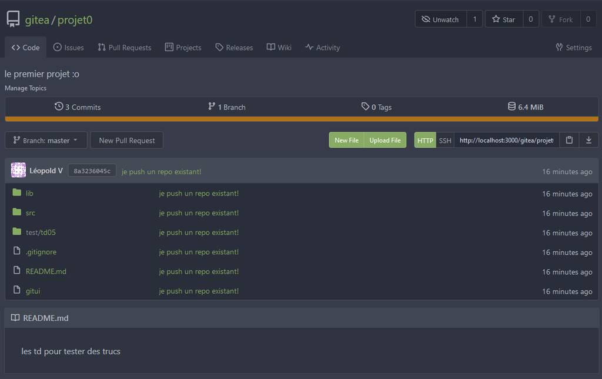

*Les changements que nous avons fait sont bien visibles sur Gitea.*

> Références : cours de R2.03.

### Q5: Comparer Gitea avec gitweb et avec le client graphique choisi précédemment.

Gitweb est l'interface web de base pour les dépôts git. Cette interface est fournie avec git nativement, et peut être utilisée en ligne de commande pour visualiser instantanément un dépôt cloné localement à l'aide d'une interface web (avec la commande `git-instaweb`).  
Cette interface offre de nombreuses fonctionnalités prêtes à l'emploi, comme la possibilité de voir tous les commits d'un dépôt, voir les différences entre des commits et/ou des branches, voir les changements par commit, etc...

[figure not shown]

*Page gitweb sur laquelle est hébergé le développement de gitweb.*

Comme on peut le voir sur la capture d'écran ci-dessus, l'interface, bien que complète et fonctionnelle, est assez brut de décoffrage. Comparé à Gitea que nous avons installé plus tôt, il y a beaucoup moins d'éléments graphiques, et aucune aide. Néanmoins, tous les éléments nécessaires à la bonne gestion d'un dépôt git sont présents.

On peut aussi noter l'absence, comme pour beaucoup d'outils bruts fournis avec git, de fonctionnalités additionnelles qui facilitent l'utilisation, comme une aide au clonage en HTTPS/SSH, la possibilité de modifier des fichiers en ligne, ou encore des outils pour collaborer comme des demandes d'ajout ou des tickets.

En ce qui concerne notre client graphique, il n'est pas réellement comparable avec Gitea. Alors que Gitea est une interface pour l'hébergement de nombreux dépôts git, GitUI nous aide à gérer un dépôt précis, cloné localement depuis Gitea ou tout autre service d'hébergement git.

Néanmoins, si nous devions comparer les deux, GitUI serait le plus facile et le plus rapide à utiliser, car étant une interface en ligne de commande, il est possible de tout faire au clavier en l'espace de quelques secondes, ce qui fait gagner beaucoup de temps. Les autres fonctionnalités comme la fusion de branche ou l'inspection des commits est également possible sur les deux plateformes, et encore une fois, il s'agit d'une question de préférence entre utiliser la souris ou le clavier. Pour notre part, nous avons choisi GitUI.

> Référence : https://git-scm.com/docs/gitweb

# Rendu 5 : Finalisation et pour aller plus loin.

## A. Finalisation du rapport

Nous avons utilisé pandoc pour réaliser notre rapport final en HTML.

Pour être sur que notre rapport notre rapport final soit bien créé à chaque fois (par exemple, que les modifications potentielles que nous faisont soient prises en compte), nous avons réalisé un script shell qui utilise les commandes pandoc. Il suffit de l'exécuter pour obtenir le rapport final.

Notre fichier `concat.sh` :

> #!/bin/bash

> pandoc --from gfm --to gfm ./Rendu*.md > RenduFinal.md  
> pandoc --from gfm --to html -s --toc --metadata title="SAÉ 2.03 - Installation Services Réseaux" -c ./RenduFinal/style.css RenduFinal.md > RenduHtml.html
- La première ligne de commande sert à concaténer tous nos rendus (Rendu*.md) dans un seul et même fichier Markdown appelé RenduFinal.md. "gfm" signifie "Github Flavoured Markdown", et est la variante de Markdown que nous utilisons. Nous l'utilisons avec "--from" et "--to" pour indiquer le langage du fichier d'entrée, et de la sortie de la commande.

  Par défaut, le résultat de la commande pandoc est écrit sur la sortie standard, c'est pourquoi nous utilisons l'opérateur ">" pour rediriger l'entrée standard vers le fichier "RenduFinal.md". Nous obtenons bien un fichier unique contenant tous nos rapports.
- La deuxième ligne de commande est celle qui permet réellement la conversion de Markdown à HTML de nos fichiers.

  Encore une fois, les deux options "--from" et "--to" permettent d'indiquer le langage d'origine (ici, Github Flavoured Markdown encore une fois), ainsi que le langage de sortie (cette fois-ci, HTML).

  L'option "-s" est une option qui sert à indiquer que la sortie de la commande devra contenir un entête et un pied de page (en HTML, des balises "header" et "footer"), pour que le fichier soit indépendant (standalone file en anglais, d'où le -s ou --standalone).

  "--toc" est une balise très utile qui sert à générer automatiquement une table des matières ("toc" pour "table of contents") en fonction des différents titres du fichier à convertir. Dans notre cas, la table des matières sera un imbriquement des différents titres de nos fichiers Markdown (précédés par des dièses). Pour que la génération soit réussie, il faut que tous les fichiers concaténés suivent les même règles de titrage, ce que nous avons respecté dans tous nos rapports.

  L'option "--metadata" permet d'ajouter des méta-données à notre document. Pour un fichier HTML, il est recommandé d'indiquer le titre de la page pour que pandoc puisse l'utiliser lors de la génération, ce que nous avons fait.  
  Dans le cas où il y aurait beaucoup de méta-données, la commande pourrait être très longue à force de lister toutes les données (mdr), on peut donc également utiliser "--metadata-file" pour fournir un fichier YAML ou JSON contenant les données, que pandoc lira et intégrera à la génération.

  Enfin, l'option "-c" permet d'inclure un fichier CSS que pandoc liera à l'HTML généré.

  Nous renseignons ensuite le fichier source, puis nous redirigons le résultat de la commande pandoc (qui, je le rappel, produit un résultat sur la sortie standard) vers le fichier RenduHtml.html avec l'opérateur ">".

En concaténant tous les fichiers Markdown de nos rapports à un seul, puis en le convertissant grâce à pandoc et plusieurs options, nous obtenons un fichier HTML final, qui ne demande plus qu'à être stylisé à l'aide de quelques règles CSS.

Nous avons ajouté une ou deux balises au fichier HTML pour avoir une meilleure page de présentation, le reste a été laissé intact.